# How effective the Covid vaccines?

*How to do it?*:

- Open the Rmarkdown file of this assignment (link) in Rstudio.
- Right under each **question**, insert a code chunk (you can use the hotkey `Ctrl + Alt + I` to add a code chunk) and code the solution for the question.
- `Knit` the rmarkdown file (hotkey: `Ctrl + Alt + K`) to export an html.
- Publish the html file to your Githiub Page.

*Submission*: Submit the link on Github of the assignment to Canvas

How effective is the covid vaccines? There are multiple analysis to answer the question. This following practice give ONE way to analyze how effective the Covid vaccines are. The analysis is done for the United States.

1. Import the two following data
- Data 1: https://raw.githubusercontent.com/owid/covid-19-data/master/public/data/vaccinations/vaccinations.csv
- Data 2: https://covid19.who.int/who-data/vaccination-data.csv

```r
library(dplyr)
library(tidyverse)
library(ggplot2)
library(gganimate)
library(lubridate)

df1 <- read_csv("https://raw.githubusercontent.com/owid/covid-19-data/master/public/data/vaccinations/vaccinations.csv")

df2 <- read_csv("~/Statistical Analysis with R/WHO-COVID-19-global-data.csv")
```

2. We will merge these two datasets in one for our analysis. We will use the `inner_join()` function to join the two datasets into one new datasets where the primary keys are Country and Date. First we need to change the names of the two datasets so that they have the same name for country and date. In dataset 1, change the name of the `location` to `Country`. In dataset 2, change the name of the variable `Date_reported` to `date`

```r
colnames(df1)[1] <- "Country"
colnames(df2)[which(names(df2)=="Date_reported")] <- "date"
```

3. In dataset 2 and variable `Country` change `United States of America` to `United States` (You can use `str_replace`)

```r
df2$Country = str_replace(df2$Country, "United States of America", "United States")
```

4. Use `inner_join(data1, data2, by = c('Country','date')` to create a new dataset.

```r
df3 <- inner_join(df1, df2, by = c("Country", "date"))
```

For more about joining data, see this datacamp course: https://app.datacamp.com/learn/courses/joining-data-with-dplyr-in-r

5. In the new dataset, create a variable `death_per_vac` by dividing the `Cumulative_deaths` by `total_vaccinations`.

```r
df3$death_per_vac <- df3$Cumulative_deaths/df3$total_vaccinations
```

6. Plot the `death_per_vac` by `date` for the United State using `geom_point`.

[figure not shown]

```r
df3 %>%
  ggplot(aes(x=date, y=death_per_vac))+
  geom_point()+
  labs(title = "Deaths per Vaccinations", x="Date", y="Deaths per Vaccinations", caption = "Deaths per Vaccinations by date in the U.S.")
```

7. Use the log transformation for the plot above for better view. Hint: add to the code above `+scale_y_continuous(trans='log')`

[figure not shown]

```r
df3 %>%
  ggplot(aes(x=date, y=death_per_vac))+
  geom_point()+
  scale_y_continuous(trans = "log")+
  labs(title = "Deaths per Vaccinations", x="Date", y="Deaths per Vaccinations", caption = "Deaths per Vaccinations by date in the U.S.")
```

8. Filter the plot above for July to current date only. Give your comments.

[figure not shown]

```r
df3 %>%
  filter(date >= "2023-07-01") %>%
  ggplot(aes(x=date, y=death_per_vac))+
  geom_point()+
  scale_y_continuous(trans = "log")+
  labs(title = "Deaths per Vaccinations", x="Date", y="Deaths per Vaccinations", caption = "Deaths per Vaccinations by date in the U.S.- Max deaths seem to be much lower than max since the start of the pandemic!")
```

```r
#From July 2023 to now, the highest numbers of deaths are much lower than the previous max number of deaths
```

9. Do the above analysis to other countries or continents. Give your comments.

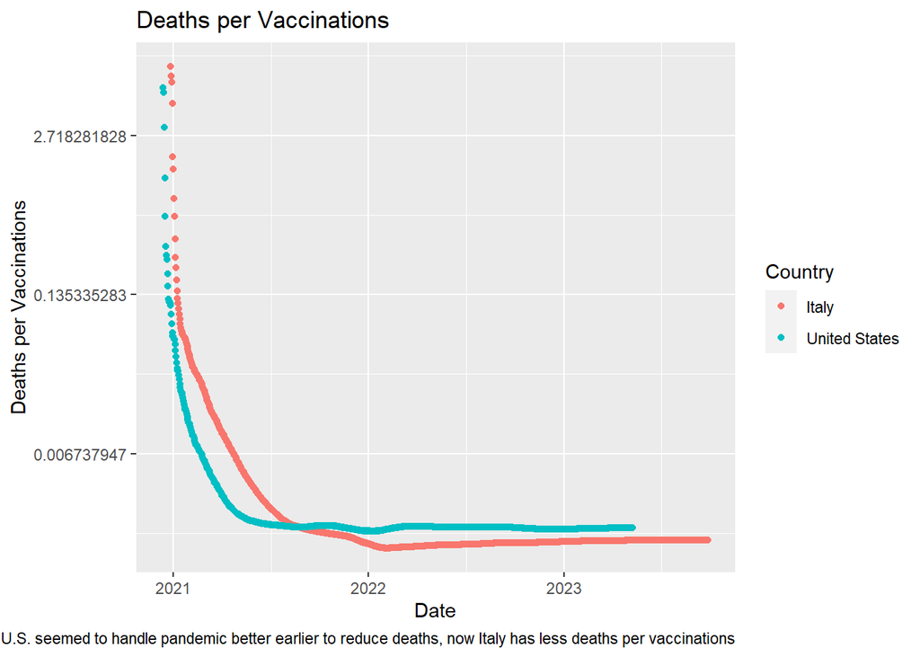

```r
df3 %>%
  filter(Country == "United States"|Country=="Italy") %>%
  ggplot(aes(x=date, y=death_per_vac, color= Country))+
  geom_point()+
  scale_y_continuous(trans = "log")+
  labs(title = "Deaths per Vaccinations", x="Date", y="Deaths per Vaccinations", caption = "Deaths per Vaccinations in U.S. vs Italy- U.S. seemed to handle pandemic better earlier to reduce deaths, now Italy has less deaths per vaccinations")
```

10. Do you have any other analysis for the effectiveness of the vaccine covid?

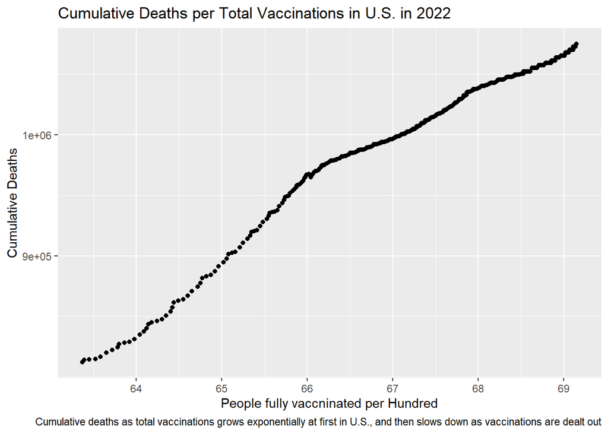

```r
df3 %>%
  filter(date>="2022-01-01") %>%
  filter(date<"2023-01-01") %>%
  filter(Country=="United States") %>%
  ggplot(aes(x=people_fully_vaccinated_per_hundred, y=Cumulative_deaths))+
  geom_point()+
  scale_y_continuous(trans = "log")+
  labs(title = "Cumulative Deaths per Total Vaccinations in U.S. in 2022", x="People fully vaccninated per Hundred", y="Cumulative Deaths", caption = "Cumulative deaths as total vaccinations grows exponentially at first in U.S., and then slows down as vaccinations are dealt out")
```